# Assignment - Week 06

Yara Roth

2026-04-01

# Setup

```r
suppressPackageStartupMessages({
  library(AnnotationHub)
  library(GenomicRanges)
  library(ggplot2)
  library(memes)
  library(motifmatchr)
  library(Biostrings)
  library(MotifDb)
  library(TFBSTools)
  library(universalmotif)
  library(PWMEnrich)
  library(GenomeInfoDb)
})
```

```
## See system.file("LICENSE", package="MotifDb") for use restrictions.
```

```r
library(rstudioapi)
setwd(dirname(rstudioapi::getActiveDocumentContext()$path))
dir.create("data")
```

# Download

## Chip-seq data

I decided to work with Chip-seq data for the TF REST from mouse myocytes.

```r
if(!file.exists("data/myocytes_REST_ENCFF368VWJ.bed.gz")) {
  download.file("https://www.encodeproject.org/files/ENCFF368VWJ/@@download/ENCFF368VWJ.bed.gz", "data/myocytes_REST_ENCFF368VWJ.bed.gz")
}

peaks <- rtracklayer::import("data/myocytes_REST_ENCFF368VWJ.bed.gz", format="NarrowPeak")

seqlevelsStyle(peaks) <- "Ensembl"
```

## Genome sequence

```r
ah <- AnnotationHub()

query_results <- AnnotationHub::query(ah, c("Mus Musculus","TwoBitFile","101","GRCm38","primary_assembly"))
head(query_results)
```

```
## AnnotationHub with 3 records
## # snapshotDate(): 2025-10-29
## # $dataprovider: Ensembl
## # $species: mus musculus
## # $rdataclass: TwoBitFile
## # additional mcols(): taxonomyid, genome, description,
## #   coordinate_1_based, maintainer, rdatadateadded, preparerclass, tags,
## #   rdatapath, sourceurl, sourcetype
## # retrieve records with, e.g., 'object[["AH84785"]]'
##
##             title
##   AH84785 | Mus_musculus.GRCm38.dna.primary_assembly.2bit
##   AH84786 | Mus_musculus.GRCm38.dna_rm.primary_assembly.2bit
##   AH84787 | Mus_musculus.GRCm38.dna_sm.primary_assembly.2bit
```

```r
genome_m <- ah[["AH84785"]]
```

```
## loading from cache
```

```
## require("rtracklayer")
```

```r
genome_seqs <- import(genome_m)
```

# Question 1:

## Motif scanning

### Getting the desired motif

We will select the motif for Mus musculus.

```r
motifs <- query(MotifDb, c("REST"))
names(motifs)
```

```
##  [1] "Hsapiens-HOCOMOCOv10-REST_HUMAN.H10MO.A"
##  [2] "Mmusculus-HOCOMOCOv10-REST_MOUSE.H10MO.A"
##  [3] "Hsapiens-HOCOMOCOv11-core-A-REST_HUMAN.H11MO.0.A"
##  [4] "NA-HOMER-REST-NRSF(Zf)/Jurkat-NRSF-ChIP-Seq/Homer"
##  [5] "Hsapiens-JASPAR_CORE-REST-MA0138.2"
##  [6] "Hsapiens-JASPAR_2014-REST-MA0138.2"
##  [7] "Hsapiens-jaspar2016-REST-MA0138.1"
##  [8] "Hsapiens-jaspar2016-REST-MA0138.2"
##  [9] "Hsapiens-jaspar2018-REST-MA0138.1"
## [10] "Hsapiens-jaspar2018-REST-MA0138.2"
## [11] "Hsapiens-jaspar2022-REST-MA0138.2"
## [12] "Hsapiens-jaspar2024-REST-MA0138.3"
## [13] "Hsapiens-SwissRegulon-REST.SwissRegulon"
## [14] "Mmusculus-UniPROBE-Irx3.UP00223"
## [15] "Mmusculus-UniPROBE-Irx3.UP00223.a272"
## [16] "Mmusculus-UniPROBE-Irx6.UP00150"
```

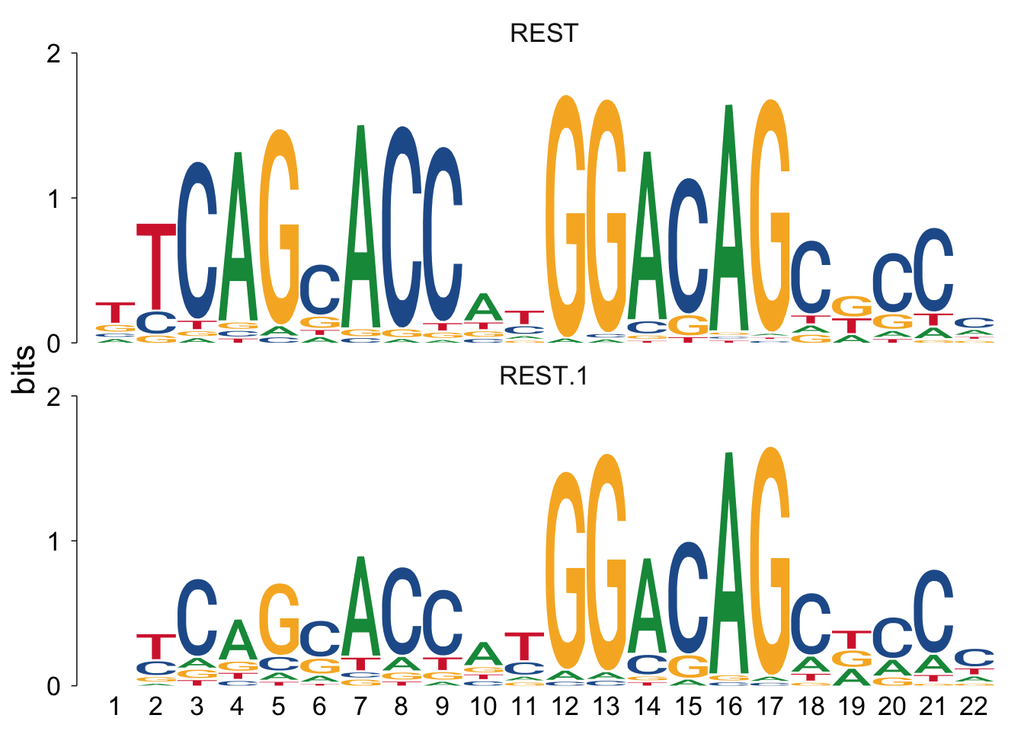

```r
motif <- motifs[["Mmusculus-HOCOMOCOv10-REST_MOUSE.H10MO.A"]]
view_motifs(motifs[1:2])
```

Next we will scan our peaks for motifs, meaning we will go through the peaks and check whether they contain REST motif matches.

```r
Biostrings::writeXStringSet(genome_seqs, "data/genome.fa")
motif2 <- convert_motifs(motif, class="TFBSTools-PWMatrix")
```

```
## Note: motif [motif] has an empty nsites slot, using 100.
```

```r
moi <- motifmatchr::matchMotifs(motif2, subject=peaks, genome=Rsamtools::FaFile("data/genome.fa"), out="positions")

moi <- moi[[1]]
head(moi)
```

```
## GRanges object with 6 ranges and 1 metadata column:
##       seqnames            ranges strand |     score
##          <Rle>         <IRanges>  <Rle> | <numeric>
##   [1]        2 33018215-33018235      + |   25.5995
##   [2]        2 33018236-33018256      + |   22.8836
##   [3]        9 56738489-56738509      + |   13.5224
##   [4]        9 56738447-56738467      - |   30.5631
##   [5]        9 21950501-21950521      + |   28.1248
##   [6]        9 21950525-21950545      - |   21.8808
##   -------
##   seqinfo: 20 sequences from an unspecified genome; no seqlengths
```

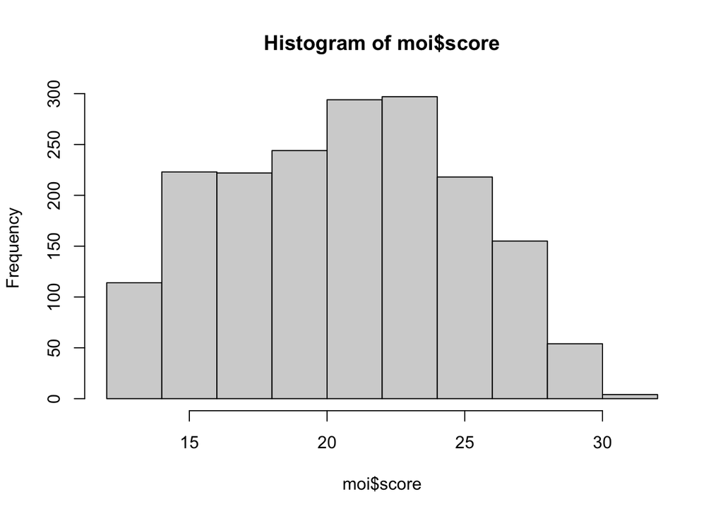

```r
hist(moi$score)
```

`moi` is an object that contains every genomic position where a REST motif match was found within a peak. Meaning we can now look at the percentage of peaks that contain an overlap with a REST motif.

```r
overlap <- table(overlapsAny(peaks, moi))
overlap
```

```
##
## FALSE  TRUE
##  1898  1657
```

```r
overlap_true <- overlap["TRUE"]

peak_count <- length(peaks)
peak_motif_proportion <- 100 / peak_count * overlap["TRUE"]
peak_motif_proportion
```

```
##     TRUE
## 46.61041
```

**ANSWER QUESTION 1**  
Of the 3555 peaks, 1657 (46.61%) contain a motif.

# Question 2:

## Scanning the whole genome

Now we will scan the whole genome for REST motif matches.

```r
motif_across_genome <- matchMotifs(motif2, subject=genome_seqs, out="positions")[[1]]
names(motif_across_genome) <- names(genome_seqs)
motif_across_genome <- as(motif_across_genome, "GRanges")
head(motif_across_genome)
```

```
## GRanges object with 6 ranges and 0 metadata columns:
##       seqnames          ranges strand
##          <Rle>       <IRanges>  <Rle>
##   [1]        1 3009026-3009046      *
##   [2]        1 3021779-3021799      *
##   [3]        1 3022783-3022803      *
##   [4]        1 3024885-3024905      *
##   [5]        1 3029113-3029133      *
##   [6]        1 3037640-3037660      *
##   -------
##   seqinfo: 66 sequences from an unspecified genome; no seqlengths
```

Now can now look at the percentage of motifs that are occupied by a the transcription factor.

```r
overlap_motif <- table(overlapsAny(motif_across_genome, peaks))
overlap_motif
```

```
##
##  FALSE   TRUE
## 599563   2253
```

```r
overlap_motif_true <- overlap_motif["TRUE"]

motif_count <- length(motif_across_genome)
motif_peak_proportion <- 100 / motif_count * overlap_motif["TRUE"]
motif_peak_proportion
```

```
##      TRUE
## 0.3743669
```

**ANSWER QUESTION 2**  
Of the 601816 motif sites, 2253 (0.37%) overlap a peak.

# This was only for me:

## Enrichment Analysis

### Preparing sequences

```r
quantile(width(peaks))
```

```
##   0%  25%  50%  75% 100%
##   50  136  136  136  393
```

```r
peak_centers <- resize(peaks, fix="center", width=100)

peak_seqs <- memes::get_sequence(peak_centers, genome_m)
peak_seqs
```

```
## DNAStringSet object of length 3555:
##        width seq                                            names
##    [1]   100 CAGGTCATCTGCTCTATGGCGC...GCTTCCAGGATGCTGACCTAC 2:33018194-33018293
##    [2]   100 TGAGGCTGTTGGCTGAAAGGAG...GAGGATGGGCACCAAGGATAG 9:56738405-56738504
##    [3]   100 GGCCGGTCAGGGAGGGAATCAC...GAGGGCAACGGAAGGTCTTAA 9:21950475-21950574
##    [4]   100 GTCGCTACCGCGGACAGCTCCC...TCTGTAGGCTTGAGATGCTGT 13:100210713-1002...
##    [5]   100 CAGCTGGTGCTGTCCATGTGGG...GTTCTGCTCACACACACACCA 11:79593651-79593750
##    ...   ... ...
## [3551]   100 CACCCACTCTCTCCTCCTCCAA...CTGGAATGCTGTCTCTGCGCC 18:35383630-35383729
## [3552]   100 CCGCTCAGGCAGAGGAAGCGGA...CCGAGACGGCGCGAGGTCGCG 15:101284291-1012...
## [3553]   100 GGGACCCTGAGGTGGGCGGAAA...GGCGACGCGGGTCTGAGGCAG 9:69398043-69398142
## [3554]   100 CGGGGCGGGTCAGCTACCCTGG...CCGTCGGAACTGAAGCCCCGG 15:89315452-89315551
## [3555]   100 GATCGGGGGACCACGGGAACGG...CACTGGCGCGCGCGGGTGCTG 10:59879854-59879953
```

```r
as.character(peak_seqs[1])
```

```
##                                                                                    2:33018194-33018293
## "CAGGTCATCTGCTCTATGGCGCCAGCACCAAGGACAGCACCGCAAGCACCAAGGACAGCACCAGGAGCACGCAGCTTTGGCTTCCAGGATGCTGACCTAC"
```

And now we will perform the actual enrichment analysis, meaning we will analyze which motifs are statisically enriched (appear more in peaks than random background).

```r
motifs <- query(MotifDb, c("Mmusculus", "HOCOMOCOv10"))
Sys.setenv(MEME_BIN = "/Users/yararoth/miniconda3/envs/epigen/bin")
ame <- memes::runAme(peak_seqs, database=convert_motifs(motifs))
head(ame)
```

```
## # A tibble: 6 × 17
##    rank motif_db  motif_id motif_alt_id consensus    pvalue adj.pvalue    evalue
##   <int> <chr>     <chr>    <chr>        <chr>         <dbl>      <dbl>     <dbl>
## 1     1 /var/fol… REST     REST_MOUSE.… YCAGCACC… 1.02e-305  2.15e-305 9.14e-305
## 2     2 /var/fol… MAF      MAF_MOUSE.H… KTGCTGAC  4.19e-133  1.26e-129 5.36e-127
## 3     3 /var/fol… RELB     RELB_MOUSE.… RGGGRMTT… 1.80e- 67  2.17e- 64 9.23e- 62
## 4     4 /var/fol… MAFB     MAFB_MOUSE.… WGCTGACDS 6.60e- 51  2.12e- 47 9.04e- 45
## 5     5 /var/fol… PRGR     PRGR_MOUSE.… AGAACAB   6.46e- 41  1.5 e- 37 6.39e- 35
## 6     6 /var/fol… TBX20    TBX20_MOUSE… RRGTGNTG… 1.73e- 34  2.98e- 31 1.27e- 28
## # ℹ 9 more variables: tests <int>, fasta_max <dbl>, pos <int>, neg <int>,
## #   pwm_min <dbl>, tp <int>, tp_percent <dbl>, fp <int>, fp_percent <dbl>
```

And now we see that the most enriched motif is REST, which confirms that the REST transcription factor actually recognizes and binds to this motif.